# F7. Hypotesis testing

Author

Ullrika Sahlin

# Hypotesis testing

**Exempel. Drunk driving**

The limit for drunk driving is 0.2 per mille. At a traffic control, three determinations of the blood alcohol level are made.

**Model:** The three measurements $x_1, x_2, x_3$ are assumed to be a sample from the random variable $X = \text{"measured alcohol level"}$, which is assumed to be normally distributed $N(\mu, 0.07)$, where $\mu$ is the true alcohol level of the person and 0.07 is a measure of the instrument’s precision.

For Kalle, the sample mean were $\bar{x}=0.27$ per mille. Should he be convicted of drunk driving?

# Hypothesis testing - basic concepts

1. Determine an appropriate probability model
2. Formulate hypotheses:
- Null hypothesis $H_0$ - “what we question”
- Alternative hypothesis $H_1$ - “what we want to prove”
3. Identify a test rule
- Determine which probabilities of error one can accept - choose significance level $\alpha$

$$\alpha = P(\text{error of type I}) = P(\text{reject }H_0|H_0\text{ is true})$$

$$\beta = P(\text{error of type II}) = P(\text{do not reject }H_0|H_1\text{ is true})$$

4. Plan data collection to get a good strength of the test

$$1-\beta \text{ is the power of the test}$$

5. Draw conclusions

**Example. Drunk driving**

Hypotheses:

$H_0: \mu \leq 0.2$

$H_1: \mu > 0.2$

**Possible fallacies**

|  | $H_0$ true Kalle is innocent | $H_1$ true Kalle is guilty |
| --- | --- | --- |
| $H_0$ not rejected Kalle is free | OK! | Type II error $\beta$ |
| $H_0$ rejected Kalle is convicted | Type I error $\alpha$ | OK! |

# Hypothesis test in three ways

- Confidence interval
- Test quantity and critical area
- With a p-value (the direct method)

**Example. Drunk driving**

We set significance level to $\alpha = 0.05$ and create a $1-\alpha$ = 95% confidence interval:

$I_{\mu}: (\bar{x}-\lambda_{\alpha}\frac{\sigma}{\sqrt{n}},\infty) = (0.27 - 1.64\frac{0.07}{\sqrt{3}},\infty) = (0.204,\infty )$

0.2 ($H_0$) is not in the range. We can therefore reject the null hypothesis and say that kalle is guilty.

# Hypothesis testing with confidence intervals

### Two-sided counter hypothesis

$H_0: \mu = \mu_0$

$H_1: \mu \neq \mu_0$

Make a two-sided confidence interval $I_{\mu}$ with confidence level $1 - \alpha$

$I_{\mu}$ does **not** cover $\mu_0$ ↔︎ $H_0$ is rejected at significance level $\alpha$

$I_{\mu}$ covers $\mu_0$ ↔︎ $H_0$ **can not** be discarded at level $\alpha$

### One-sidig counter hypothesis

$H_0: \mu \leq \mu_0$

$H_1: \mu > \mu_0$

Make a downward bounded confidence interval $I_{\mu}$ with confidence level $1 - \alpha$

$I_{\mu}$ does **not** cover $\mu_0$ ↔︎ $H_0$ is rejected at significance level $\alpha$

$I_{\mu}$ covers $\mu_0$ ↔︎ $H_0$ **can not** be discarded at level $\alpha$

# Hypothesis testing and error risk

**Example. Drunk driving**

In our previous test, there was a 5% risk that we are wrong, and Kalle is judged incorrectly. What happens if we reduce the risk of error to $\alpha = 1\%$?

$I_{\mu}: (\bar{x}-\lambda_{0.01}\frac{\sigma}{\sqrt{n}},\infty) = (0.27 - 2.33\frac{0.07}{\sqrt{3}},\infty) = (0.176,\infty )$

0.2 ($H_0$) is now in the range. We therefore **cannot** reject the null hypothesis. The decision is **not** to convict Kalle.

# The null hypothesis is never true

> One should never conclude that the null hypothesis is true!

$H_0$ cannot be rejected ⇏ $H_0$ is true

> Instead, one can reject or not reject the null hypothesis

**Warning**

You see an animal

$H_0: \text{it is a horse}$

$H_1: \text{it is not a horse}$

**Test:** $H_0$ is rejected if the number of legs is something else than 4

**Observation:** The animal has four legs

**Conclusion:** $H_0$ cannot be rejected

> It would be wrong to say that $H_0$ is true because there can be animals other than horses that have four legs

# Hypothesis testing with test quantity and critical region

**Model:** $X$ is a normally distributed random variable with unknown expected value $\mu$ and known standard deviation $\sigma$

**Observations:** Random sample $x_1, \dots, x_n$

**Estimation:** The expected value is estimated with the sample mean $\hat{\mu} = \bar{x}$

**Hypotheses:** $H_0: \mu = \mu_0$ and $H_1: \mu \neq \mu_0$

1. Derive the sampling distribution for the estimator when $H_0$ is true

$$\bar{x}|H_0 \text{ true}\sim N(\mu_0, \frac{\sigma}{\sqrt{n}})$$

2. Investigate whether the value of the estimator appears to lie in the sampling distribution by forming a critical region where it can be considered that it does not
3. Reject $H_0$ if the calculated value of the estimator is outside the critical range

For example: Reject $H_0$ if $\bar{x} > \mu_0 + \lambda_{\alpha}\frac{\sigma}{\sqrt{n}}$

Alternatively: Reject $H_0$ if $z = \frac{\bar{x}- \mu_0}{\sigma/\sqrt{n}} > \lambda_{\alpha}$

$z$ is a test quantity

### Illustration of critical area

One can illustrate the test with the hypothesis function found in Räknamedvariation. There, the average value is compared with a critical area controlled by $k$.

```r
source("kod/funktioner_raknamedvariation_light.R")
```

**Example. Drunk driving**

Significance level $\alpha=5\%$

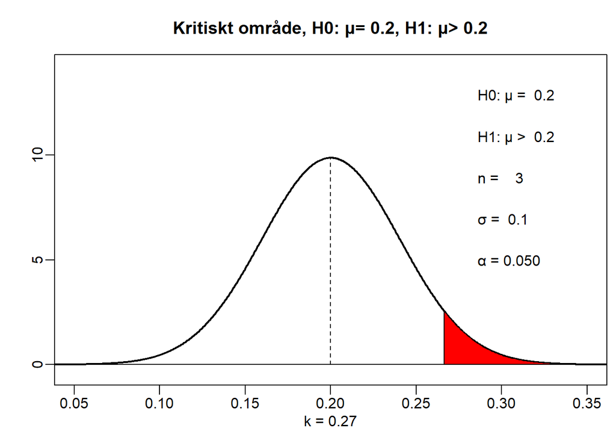

```r
hypotes(sigma=0.07,n=3,mu0=0.2,alfa=0.05,riktning=">")
```

⇒ $H_0$ rejected because $\bar{x}=0.27$ is in the critical region.

Significance level $\alpha=1\%$

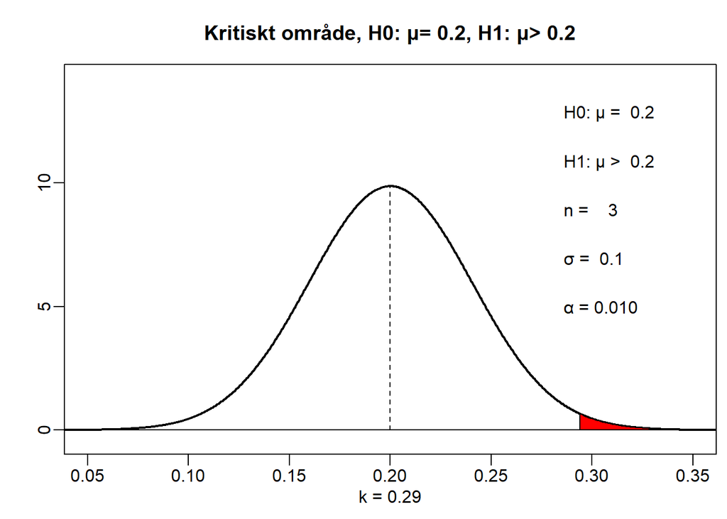

```r
hypotes(sigma=0.07,n=3,mu0=0.2,alfa=0.01,riktning=">")
```

⇒ $H_0$ **not** rejected because $\bar{x}=0.27$ **is not** in the critical region

# Probability of failure when $H_0$ is true

Let’s make sure that the test rule with the test variable gives the desired probability of failure, i.e. that $P(\text{Type I error}) = \alpha$

**Example: Drunk driving**

$\begin{split} & P(\text{Type I error}) = P(\text{Kalle is convicted despite being innoncent}) = \\ & P(H_0\text{ reject although } H_0 \text{ is true}) = \\ & P(\frac{\bar{x}- \mu_0}{\sigma/\sqrt{n}} > \lambda_{\alpha})=\alpha \end{split}$

# Test quantity with two-sided counter hypothesis

A two-sided counter-hypothesis for the drunk driving can be

$H_0: \mu = 0.2$ against $H_1: \mu \neq 0.2$

The test quantity is compared against a critical region in both tails of the sampling distribution.

Reject $H_0$ if $z = |\frac{\bar{x}- \mu_0}{\sigma/\sqrt{n}}| > \lambda_{\alpha/2}$

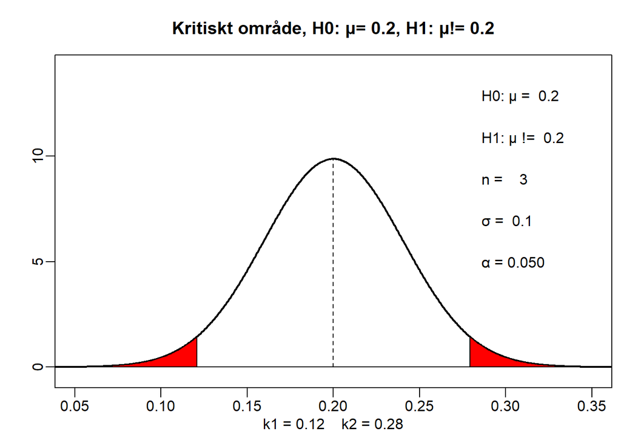

```r
hypotes(sigma=0.07,n=3,mu0=0.2,alfa=0.05,riktning="!=")
```

# Summary

**Hypotheses:**

$H_0: \mu = \mu_0$

$H_1: \mu \neq \mu_0$

## Confidence interval

**Confidence interval:**

If $\sigma$ is known:

$I_{\mu}: \bar{x} \pm \lambda_{\alpha/2}\frac{\sigma}{\sqrt{n}}$

If $\sigma$ is unknown and estimated with $s$:

$I_{\mu}: \bar{x} \pm t_{\alpha/2}(n-1)\frac{s}{\sqrt{n}}$

**Rule:** Reject $H_0$ if $\mu_0$ is not in the range $I_\mu$

## Test quantity with critical area

**Test quantity:**

If $\sigma$ is known:

$z = |\frac{\bar{x}-\mu_0}{\sigma/\sqrt{n}}|$

If $\sigma$ is unknown and estimated with $s$:

$t = |\frac{\bar{x}-\mu_0}{s/\sqrt{n}}|$

**Rule:** Reject $H_0$ if $z > \lambda_{\alpha/2}$ alternatively if $t > t_{\alpha/2}(n-1)$

## Hypothesis testing with the direct method

**Rule:** Reject $H_0$ if

$\begin{split} & \text{p-value} = \\& P(\text{"to get what we got or worse"}|H_0 \text{ is true}) < \alpha \end{split}$

**Example. Drunk driving**

**Hypotheses:**

$H_0: \mu \leq 0.2$ against $H_1: \mu > 0.2$

$\begin{split} & \text{p-value} = P(\bar{x} \geq 0.27|\mu = 0.2) = \\ & P(\frac{\bar{x}-\mu}{\sigma/\sqrt{n}} \geq \frac{0.27 - 0.2}{0.07/\sqrt{3}}) = P(Z \geq \sqrt{3}) = 1-\Phi(\sqrt{3}) = \\ & 1 - \Phi(1.73) = 1 - 0.958 =0.042 \end{split}$

**Rule:** Reject $H_0$ because the p-value is less than the chosen significance level of 0.05.

If we had chosen a significance level of 0.01 instead, we would **not** have rejected instead because the p-value is higher than the chosen significance level.

**Do not change the significance level during the test**

You must select a significance level before doing the test. It is unfortunately common for researchers/statisticians to choose the lowest significance level which leads to the rejection of the null hypothesis, but this leads in the long run to overconfidence in results.

Significance level is determined when planning a study.

# Hypothesis testing three ways

**Example: radon**

We make 10 measurements of radon in a house. Every radon measurement has a measurement error that we can say is normally distributed. The random variable $X$ is normally distributed. $X \sim N(\mu,\sigma)$ where the expected value is the true radon value and where measurement error can be described as a systematic random variation around the expected value, where $\sigma=3$.

The sample mean is $\bar{x} = 195$ $Bq/m^3$.

We want to test if the radon level is lower than 200 $Bq/m^3$ with a significance level of $\alpha = 0.05$.

$H_0: \mu \geq 200$

$H_1: \mu < 200$

### Test with a confidence interval

We create an upward one-sided confidence interval

$I_{\mu} : (-\infty, \bar{x} + \lambda_{\alpha} \cdot \frac{\sigma}{\sqrt{n}}) = (-\infty, 195 + 1.64 \cdot \frac{3}{\sqrt{10}}) = (-\infty, 196.6)$

$H_0$ is rejected with a significance level of $\alpha=5\%$ because the range does not cover 200.

### Test with test quantity and critical area

We define the test variable $z$ as

$z=\frac{\bar{x}-\mu_0}{\sigma/\sqrt{n}} = \frac{195-200}{3/\sqrt{10}} = -5.3$

The test quantity is compared to the quantile of the distribution of the test variable if the null hypothesis is true $\lambda_{0.05} = -1.645$

$H_0$ is rejected at a significance level of 5% because the test quantity $z$ is extreme under the null hypothesis.

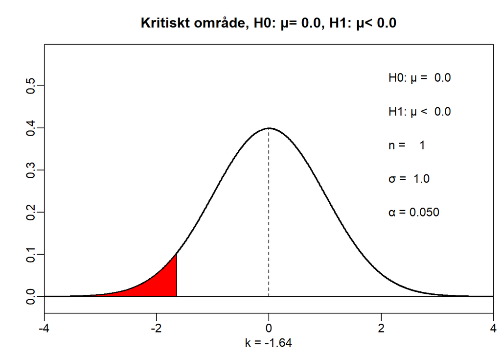

```r
hypotes(sigma=1,n=1,mu0=0,alfa=0.05,riktning="<")
```

### Test with a p-value (direct method)

The direct method involves calculating *the probability that we got what we got or worse if the null hypothesis is true*. In the case of radon, it is that one measures a level that is lower than that which was measured given that the expected value is 200.

$\begin{split} & P(\bar{x} < 195|\mu = 200) = P(\frac{\bar{x}-\mu_0}{\sigma/\sqrt{n}} < \frac{195-200}{3/\sqrt{10}}) = \\ & P(Z < -5.27) = \Phi(-5.27) = 1 - \Phi(5.27) = \\ & 1-0.99 = 6.8040115\times 10^{-8} \end{split}$

Since the p-value is lower than the chosen significance level of 5%, we reject the null hypothesis.

# Power of an hypothesis test

**Example: Drunk driving**

**Some interesting questions:**

1. Assume that Kalle’s alcohol content is $\mu = 0.25$ (drunk), what is the probability that, using the above technique, we will discover that he is drunk and thus declare him guilty?
2. We will do $n$ measurements of alcohol content. Suppose we have a requirement that says that if Kalle has an alcohol content of $\mu = 0.3$, then we shall declare him guilty with a high probability (e.g. 0.99). How many measurements must we take in order for the requirement to be met?

## Power definition

The probability of rejecting the null hypothesis when it is false is the power of a test.

The strength depends on the true value of the parameter being tested.

$S(\mu) = P(\text{Reject }H_0 |\mu\text{ is the true expected value})$

The power is $1-\beta = 1 - P(\text{Type II error})$

**Example: Drunk driving**

**Hypotheses:** $H_0: \mu = 0.2$ against $H_1: \mu > 0.2$

**Significance level:** $\alpha = 0.05$

**Test rule:** Reject $H_0$ if $\bar{x} > \mu_0 + \lambda_{\alpha}\frac{\sigma}{\sqrt{n}} = 0.2 + 1.64 \frac{0.07}{\sqrt{3}} = 0.27$

$\begin{split} & S(\mu) = P(\bar{x} > 0.27|\mu) = P(\frac{\bar{x}-\mu}{\sigma/\sqrt{n}} > \frac{0.27-\mu}{0.07/\sqrt{3}}) = // & P(Z > \frac{0.27-\mu}{0.07/\sqrt{3}}) = 1 - \Phi(\frac{0.27-\mu}{0.07/\sqrt{3}}) \end{split}$

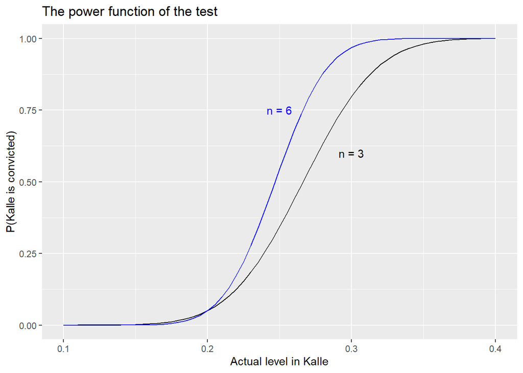

```r
df <- data.frame(mu = seq(0.1,0.4,by=0.005)) # possible mu-values
n = 3
k = 0.2+1.64*0.07/sqrt(n)
df$styrka_mu_n3 <- 1 - pnorm((k-df$mu)/(0.07/sqrt(n))) # power when n=3
n = 6
k = 0.2+1.64*0.07/sqrt(n)
df$styrka_mu_n6 <- 1 - pnorm((k-df$mu)/(0.07/sqrt(n)))

ggplot(df,aes(x=mu,y=styrka_mu_n3)) +
  geom_line() +
  geom_line(aes(x=mu,y=styrka_mu_n6), col = 'blue') +
  ylab("P(Kalle is convicted)") +
  xlab("Actual level in Kalle") +
  ggtitle("The power function of the test") +
  annotate("text",x = 0.3, y = 0.6, label = "n = 3") +
  annotate("text",x = 0.25, y = 0.75, label = "n = 6", col = "blue")
```

The power function is influenced by

-The true value of the parameter $\mu$

- The sample size $n$
- The variance in the population $\sigma^2$
- The level of significance - the lower $\alpha$, the worse strength

> A hypothesis test involves a trade-off between making type I and type II errors

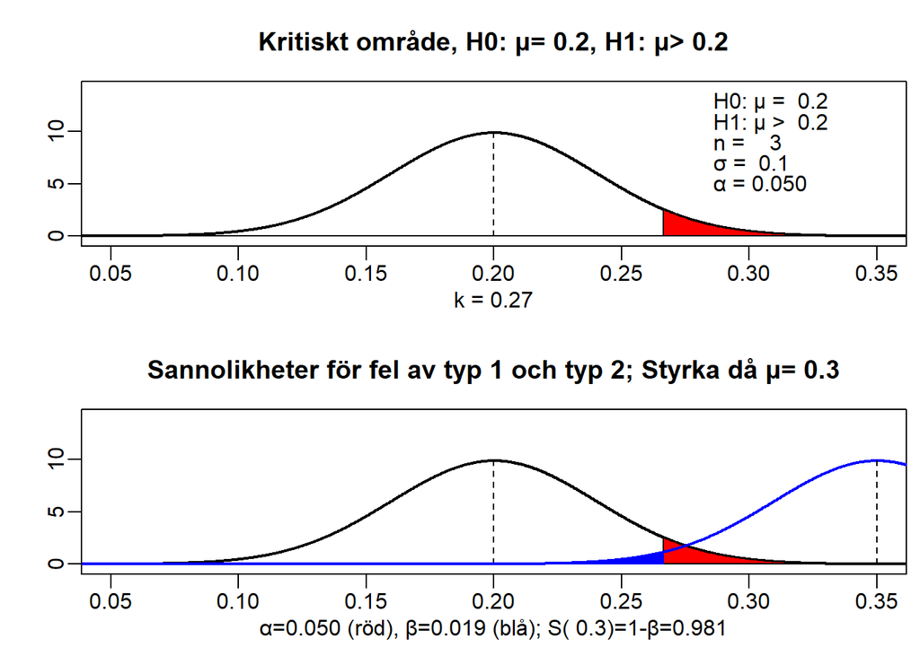

```r
hypotes(sigma=0.07,n=3,mu0=0.2,alfa=0.05,riktning=">",mu.sant = 0.35)
```

**Example: Food coloring**

A pharmaceutical manufacturer uses a certain food coloring. You want to know how the color affects the appearance of the medicine. Without the dye, turbidity is usually 4.0.  
**Model:** $X = \text{"Turbidity"}$ $X \sim N(\mu, 0.2)$

Turbidity is measured on $n=10$ randomly selected tablets. The sample mean of the turbidity was $\bar{x}=4.1$.

1. Test if the drug is to turbid at a significance level $\alpha = 0.05$

**Hypotheses:** $H_0: \mu = 4.0$ against $H_1: \mu > 4.0$

**Test rule:** Reject $H_0$ if $\bar{x} > \mu_0 + \lambda_{0.05}\frac{\sigma}{\sqrt{n}} = 4.0 + 1.64 \frac{0.2}{\sqrt{10}} = 4.104$

⇒ We cannot reject $H_0$

$\begin{split} & S(\mu) = P(\text{Reject }H_0|\mu = 4.3) = \\ & P(\bar{x} > 4.104|\mu = 4.3) = P(\frac{\bar{x}-\mu}{\sigma/\sqrt{n}} > \frac{4.104-4.3}{0.2/\sqrt{10}}) = \\ & P(Z >-3.1) = 1-\Phi(-3.1) = \Phi(3.1) = 0.999 \end{split}$

⇒ The power is 0.999